# R Notebook

```r
# Show first 5 entries of dataset
so_20 <- dbGetByQuery("SELECT * FROM survey_results_public LIMIT 5")

so_20_schema <- dbGetByQuery("SELECT * FROM survey_results_schema LIMIT 5")

so_20[1:5,]
```

|  | Respondent | MainBranch | Hobbyist | OpenSourcer | OpenSource | Employment | Country | Student | EdLevel | UndergradMajor | EduOther | OrgSize | DevType | YearsCode | Age1stCode | YearsCodePro | CareerSat | JobSat | MgrIdiot | MgrMoney | MgrWant | JobSeek | LastHireDate | LastInt | FizzBuzz | JobFactors | ResumeUpdate | CurrencySymbol | CurrencyDesc | … |
| --- | --- | --- | --- | --- | --- | --- | --- | --- | --- | --- | --- | --- | --- | --- | --- | --- | --- | --- | --- | --- | --- | --- | --- | --- | --- | --- | --- | --- | --- | --- |
| 1 | 1 | I am a student who is learning to code | Yes | Never | The quality of OSS and closed source software is about the same | Not employed, and not looking for work | United Kingdom | No | Primary/elementary school | NA | Taught yourself a new language, framework, or tool without taking a formal course | NA | NA | 4 | 10 | NA | NA | NA | NA | NA | NA | NA | NA | NA | NA | NA | NA | NA | NA | … |
| 2 | 2 | I am a student who is learning to code | No | Less than once per year | The quality of OSS and closed source software is about the same | Not employed, but looking for work | Bosnia and Herzegovina | Yes, full-time | Secondary school (e.g. American high school, German Realschule or Gymnasium, etc.) | NA | Taken an online course in programming or software development (e.g. a MOOC) | NA | Developer, desktop or enterprise applications;Developer, front-end | NA | 17 | NA | NA | NA | NA | NA | NA | I am actively looking for a job | I've never had a job | NA | NA | Financial performance or funding status of the company or organization;Specific department or team I'd be working on;Languages, frameworks, and other technologies I'd be working with | Something else changed (education, award, media, etc.) | NA | NA | … |
| 3 | 3 | I am not primarily a developer, but I write code sometimes as part of my work | Yes | Never | The quality of OSS and closed source software is about the same | Employed full-time | Thailand | No | Bachelors degree (BA, BS, B.Eng., etc.) | Web development or web design | Taught yourself a new language, framework, or tool without taking a formal course | 100 to 499 employees | Designer;Developer, back-end;Developer, front-end;Developer, full-stack | 3 | 22 | 1 | Slightly satisfied | Slightly satisfied | Not at all confident | Not sure | Not sure | Im not actively looking, but I am open to new opportunities | 1-2 years ago | Interview with people in peer roles | No | Languages, frameworks, and other technologies I'd be working with;Remote work options;Flex time or a flexible schedule | I was preparing for a job search | THB | Thai baht | … |
| 4 | 4 | I am a developer by profession | No | Never | The quality of OSS and closed source software is about the same | Employed full-time | United States | No | Bachelors degree (BA, BS, B.Eng., etc.) | Computer science, computer engineering, or software engineering | Taken an online course in programming or software development (e.g. a MOOC);Received on-the-job training in software development;Taught yourself a new language, framework, or tool without taking a for… | 100 to 499 employees | Developer, full-stack | 3 | 16 | Less than 1 year | Very satisfied | Slightly satisfied | Very confident | No | Not sure | I am not interested in new job opportunities | Less than a year ago | Write code by hand (e.g., on a whiteboard);Interview with people in senior / management roles | No | Languages, frameworks, and other technologies I'd be working with;Office environment or company culture;Opportunities for professional development | I was preparing for a job search | USD | United States dollar | … |
| 5 | 5 | I am a developer by profession | Yes | Once a month or more often | OSS is, on average, of HIGHER quality than proprietary / closed source software | Employed full-time | Ukraine | No | Bachelors degree (BA, BS, B.Eng., etc.) | Computer science, computer engineering, or software engineering | Taken an online course in programming or software development (e.g. a MOOC);Received on-the-job training in software development;Taught yourself a new language, framework, or tool without taking a for… | 10,000 or more employees | Academic researcher;Developer, desktop or enterprise applications;Developer, full-stack;Developer, mobile | 16 | 14 | 9 | Very dissatisfied | Slightly dissatisfied | Somewhat confident | Yes | No | I am not interested in new job opportunities | Less than a year ago | Write any code;Write code by hand (e.g., on a whiteboard);Solve a brain-teaser style puzzle;Interview with people in senior / management roles | No | Industry that I'd be working in;Languages, frameworks, and other technologies I'd be working with;Flex time or a flexible schedule | I was preparing for a job search | UAH | Ukrainian hryvnia | … |

# Initial Assessment

```r
#sprintf('The 2020 survey had %d respondents and %d variables.', dim(so_20)[1], dim(so_20)[2])

#head(so_20_schema)
```

```r
# Load world data
world <- ne_countries(scale = "medium", returnclass = "sf")

# Create dataframe with all available countries
worldframe <- data.frame(x = world$name)

# Create dataframe with all survey countries
countries <- dbGetByCol(
  col = "Country"
)

countries <- countries %>% count(Country)

# Rename col for joining
countries <- countries %>%
  rename(
    x = Country
  )

# Join both dataframes together
world$surveyPop <- join(worldframe, countries, by='x')

# Change NA to 0
world$surveyPop[is.na(world$surveyPop)] <- 0
```

# Geography

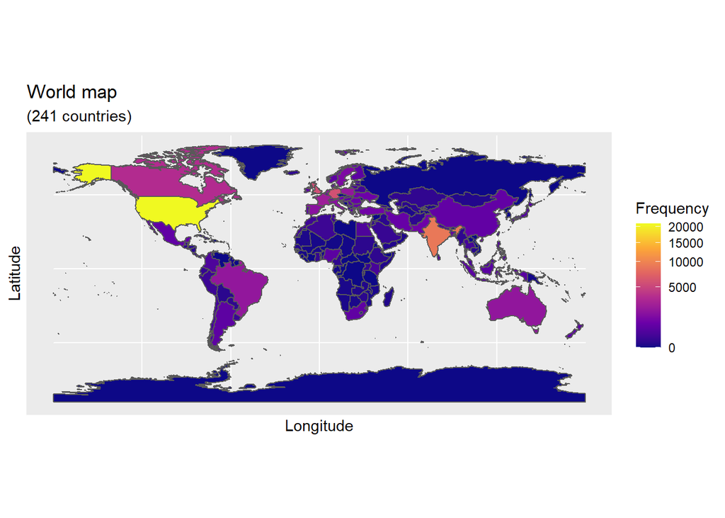

```r
# Plot world map
worldpopmap <- ggplot(data=world) +
  # Set plot title
  ggtitle("World map", subtitle = paste0("(", length(unique(world$name)), " countries)")) +
  # Set x and y label
  xlab("Longitude") + ylab("Latitude") +
  # Fill worldmap with summarized survey data
  geom_sf(aes(fill = world$surveyPop$n)) +
  # Scale colors
  scale_fill_viridis_c(option = "plasma", trans = "sqrt") +
  # Customize legend title
  labs(fill = 'Frequency')

# display map
worldpopmap
```

```r
# Show previously plotted data in numbers

countries %>%
  arrange(-n)
```

| x | n |
| --- | --- |
| United States | 20949 |
| India | 9061 |
| Germany | 5866 |
| United Kingdom | 5737 |
| Canada | 3395 |
| France | 2391 |
| Brazil | 1948 |
| Poland | 1922 |
| Australia | 1903 |
| Netherlands | 1852 |

[output cut: 169 more lines]

# Developer Roles

About 55% of respondents identify as full-stack developers, and about 20% consider themselves mobile developers. The median number of developer type identifications per respondent this year is three, and the most common combinations include back-end, front-end, and full-stack developer. Pairs that are highly correlated include database administrator and system administrator, DevOps specialist and site reliability engineer, academic researcher and scientist, and designer and front-end developer.

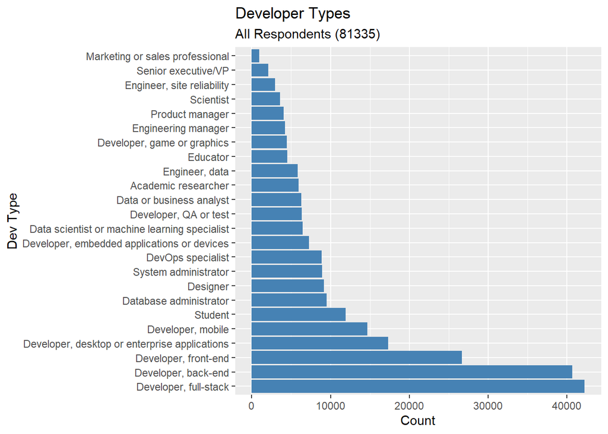

```r
devTypes <- dbGetByCol(
  col = "DevType"
)

dT_split <- strsplit(devTypes$DevType, split=";")
dT_flatten <- unlist(dT_split)
dT <- data.frame(matrix(dT_flatten))

colnames(dT) <- colnames(devTypes)

dT %>%
  ggplot( aes(x = fct_infreq(DevType))) +
    geom_bar(fill='steelblue')+
    xlab("Dev Type") +
    coord_flip() +
    labs(title = "Developer Types",
         subtitle = paste0("All Respondents (", nrow(devTypes) ,")"),
         y = 'Count')
```

## Job Satisfactory

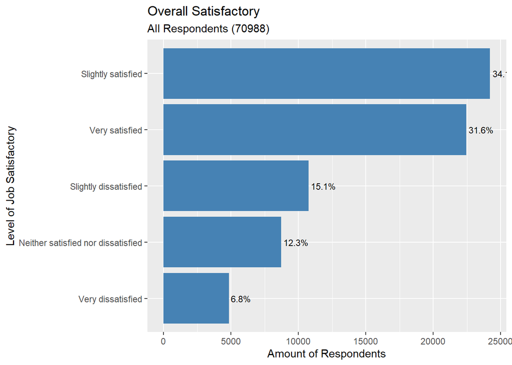

```r
sat <- dbGetByCol(
  col = "JobSat"
)

# Plot Overall Satisfactory
sat %>% count(JobSat) %>% arrange(n) %>% mutate(pct = prop.table(n), JobSat = fct_reorder(JobSat, n)) %>%
  ggplot(aes(
    x=JobSat,
    y=n,
    label= scales::percent(pct))) +
    geom_col(position = 'dodge', fill = 'steelblue') +
    geom_text(position = position_dodge(width = .9),    # move to center of bars
              vjust = 0.5,    # nudge above top of bar
              hjust = -0.1,
              size = 3) +
    xlab("Level of Job Satisfactory") +
    ylab("Amount of Respondents") +
    labs(title = "Overall Satisfactory",
         subtitle = paste0("All Respondents (", nrow(sat) ,")")) +
    coord_flip()
```

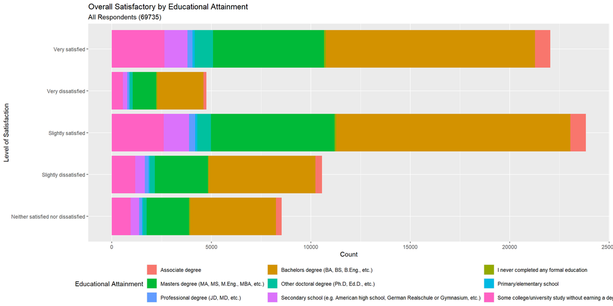

```r
# Plot Satisfactory dependent with educational attainment

satByEdu <- dbGetByQuery(
  query = "SELECT count(JobSat) as cJobSat,JobSat,EdLevel
FROM survey_results_public
WHERE JobSat IS NOT NULL
AND EdLevel IS NOT NULL
GROUP BY JobSat, EdLevel
ORDER BY cJobSat DESC;"
)

satByEdu[,"cJobSat"] <- as.integer(satByEdu[,"cJobSat"])

satByEdu %>%
  ggplot(aes(
    x = JobSat,
    y = cJobSat,
    fill = EdLevel
  )) + geom_bar(stat = "identity") +
  theme(legend.position="bottom",
        legend.box="vertical",
        legend.margin=margin()
        ) +
  ylab("Count") + xlab("Level of Satisfaction") +
  labs(
    fill = "Educational Attainment",
    title = "Overall Satisfactory by Educational Attainment",
    subtitle = paste0("All Respondents (", sum(satByEdu$cJobSat) ,")")
  ) + coord_flip() + guides(fill=guide_legend(nrow=3,byrow=TRUE))
```

## Coding as a hobby

Many developers work on code outside of work. About 78% of our respondents say that they code as a hobby. Other responsibilities outside of software can reduce developers’ engagement in coding as a hobby; developers who say they have children or other caretaking responsibilities are less likely to code as a hobby. Respondents who are women are also less likely to say they code as a hobby.

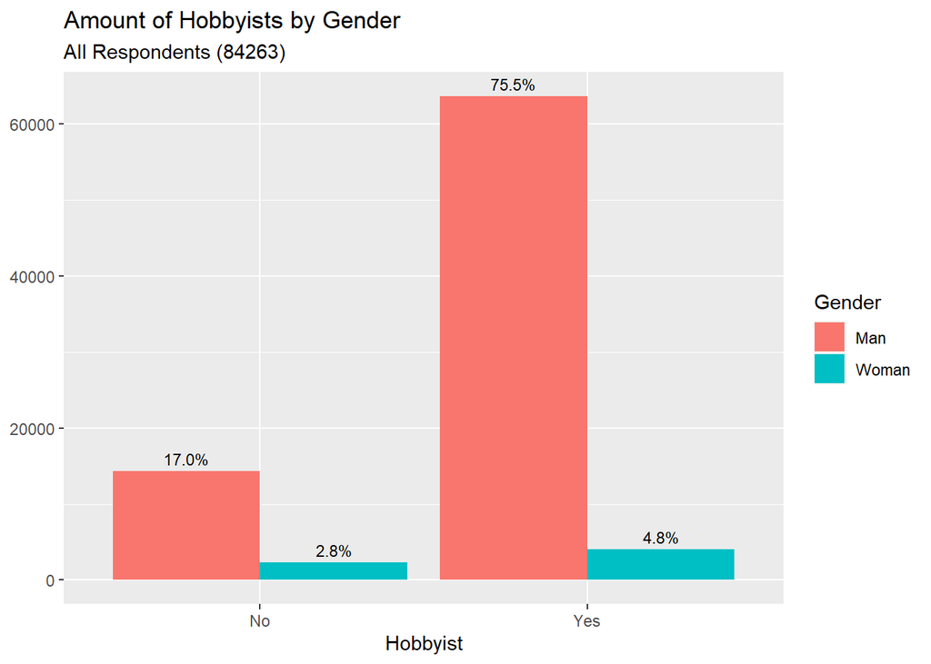

```r
hobby <- dbGetByQuery("SELECT
Hobbyist,
count(Hobbyist) as CountHobbyist,
Gender
FROM new_schema.survey_results_public
WHERE
Gender = 'Woman' or
Gender = 'Man'
group by
Hobbyist,
Gender;
")

hobby[,"CountHobbyist"] <- as.integer(hobby[,"CountHobbyist"])

hobby <- hobby %>% mutate(pct = prop.table(CountHobbyist))

# Create reusable plot without data
gg_hobby <- ggplot(data = data.frame(), aes(x = Hobbyist,
                                            y = CountHobbyist,
                                            fill=Gender,
                                            label= scales::percent(pct))) +
  geom_col(position = 'dodge') +
  geom_text(position = position_dodge(width = .9),    # move to center of bars
              vjust = -0.5,    # nudge above top of bar
              size = 3) +
  labs(x = 'Hobbyist',
       y = NULL,
       fill= 'Gender',
       title= 'Amount of Hobbyists by Gender',
       subtitle= paste0("All Respondents (", sum(hobby$CountHobbyist) ,")"))

# Add data after
gg_hobby %+%
  hobby
```